# Data Privacy Survey

#### Veterinary Medicine

Storage media used in the Faculty of Veterinary Medicine.

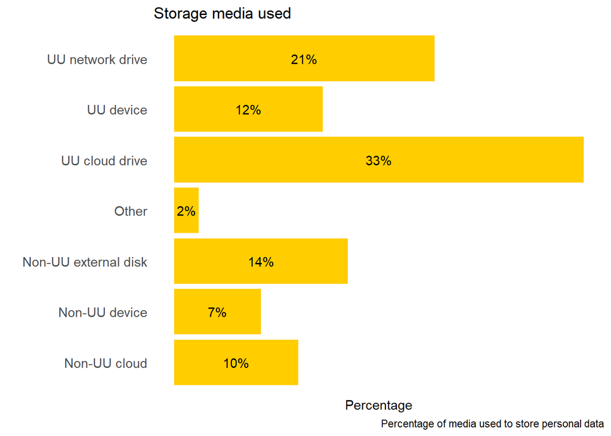

#### LEG

Storage media used in the Faculty of Law, Economics and Governance.

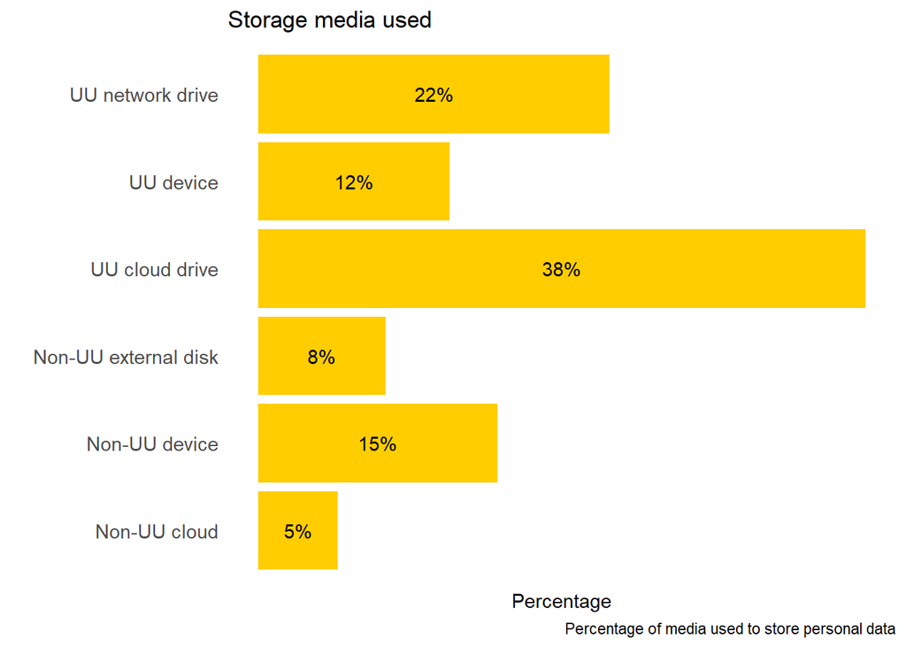

#### Geo

Storage media used in the Faculty of Geosciences.

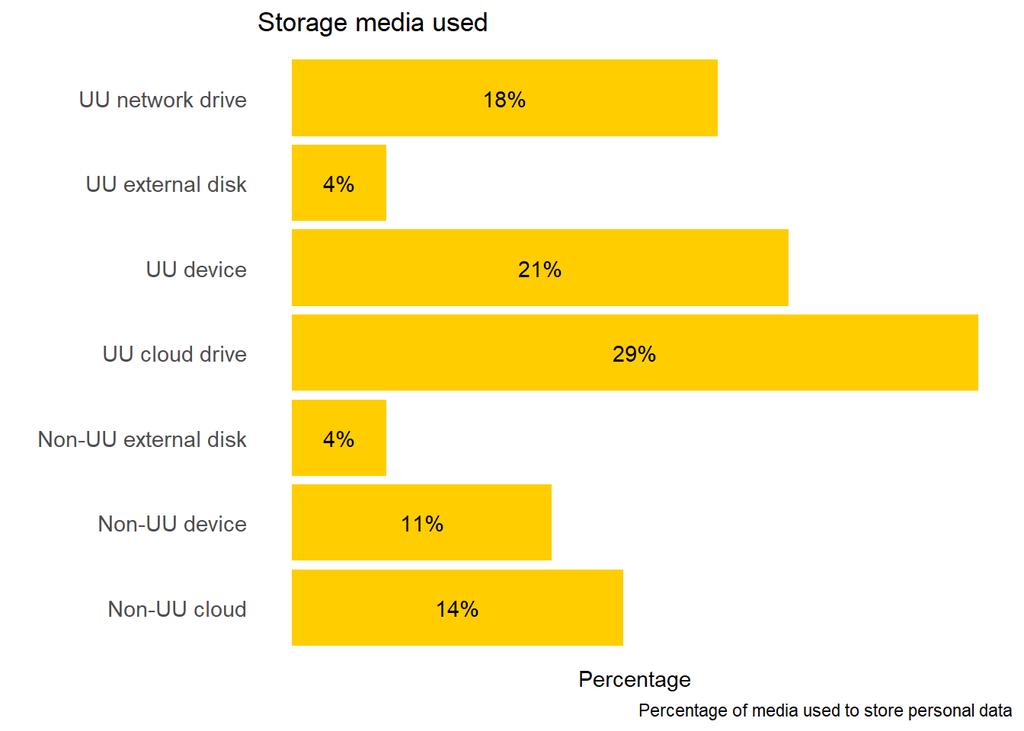

### Consent forms

#### UU-wide

Consent is currently the legal basis most often used in researcher performed at UU. Luckily, only a small number of respondents indicated that consent forms are not applicable to their research or they don’t know what they are. The consent forms most often used seem to be approved by privacy officers or ethical committees. Some respondents however indicated to independently create and use consent forms. A handful of respondents indicated to use templates from external institutions, or no templates at all (e.g., because they use verbal consent or data from another party).

The mere fact that researchers make use of a consent form and information letter of course does not mean these forms are of sufficient quality. Therefore, we asked respondents what they typically include in their information to participants. Most respondents indicated to provide at least the basic information on the purposes for data collection and which data will be be used. Information on the data subjects’ rights and safeguards are often included as well.

Information and consent on data sharing and reuse is apparently not included as often. This is a point of concern, because not obtaining consent for sharing personal data for reuse may mean that data collected for a specific research project may not be reused again, reducing the scientific value of the data.

Finally, contact details of the Data Protection Officer (DPO) are not always included either, whereas these always have to be provided when working with personal data ([art. 13](https://gdpr-info.eu/art-13-gdpr/))

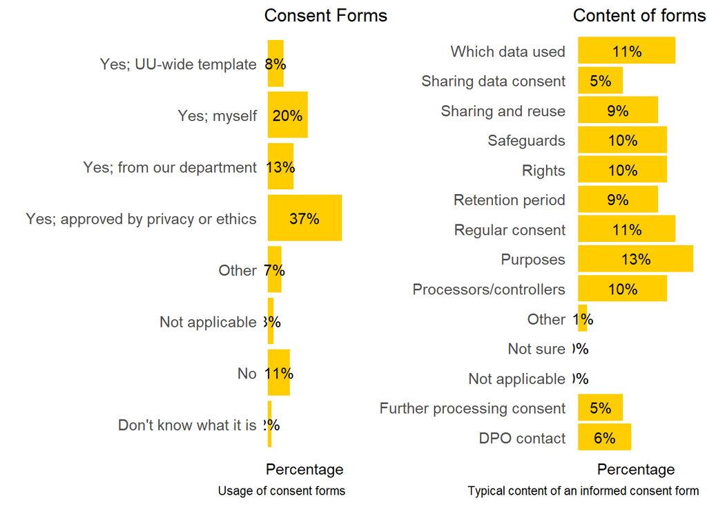

#### Science

Below the usage and content of informed consent forms at the Science faculty is displayed.

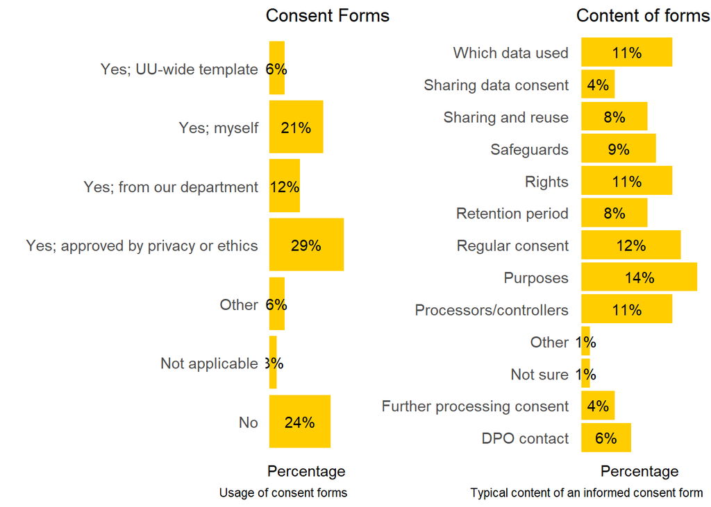

#### FBSB

Below the usage and content of informed consent forms at the Faculty of Social and Behavioural Sciences (FSBS) is displayed.

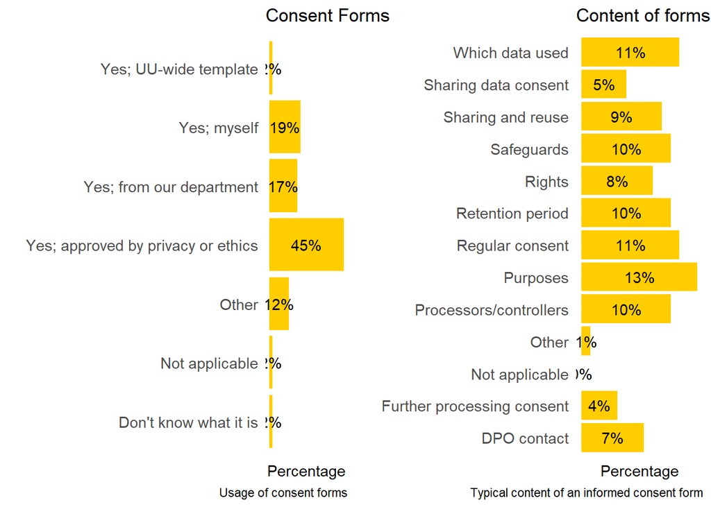

#### Humanities

Below the usage and content of informed consent forms at the Faculty of Humanities is displayed.

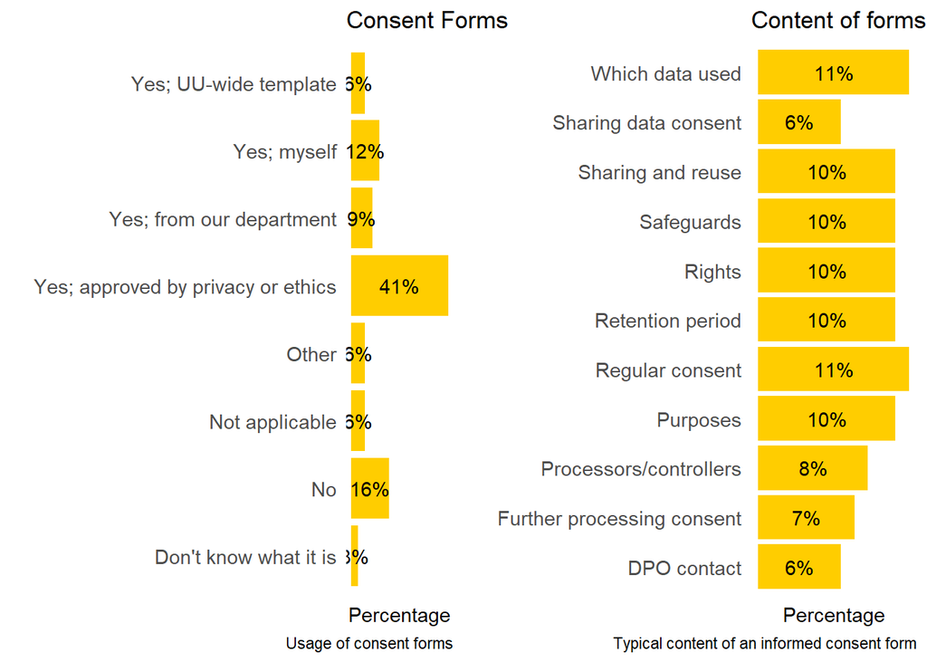

#### Veterinary Medicine

Below the usage and content of informed consent forms at the Faculty of Veterinary Medicine is displayed.

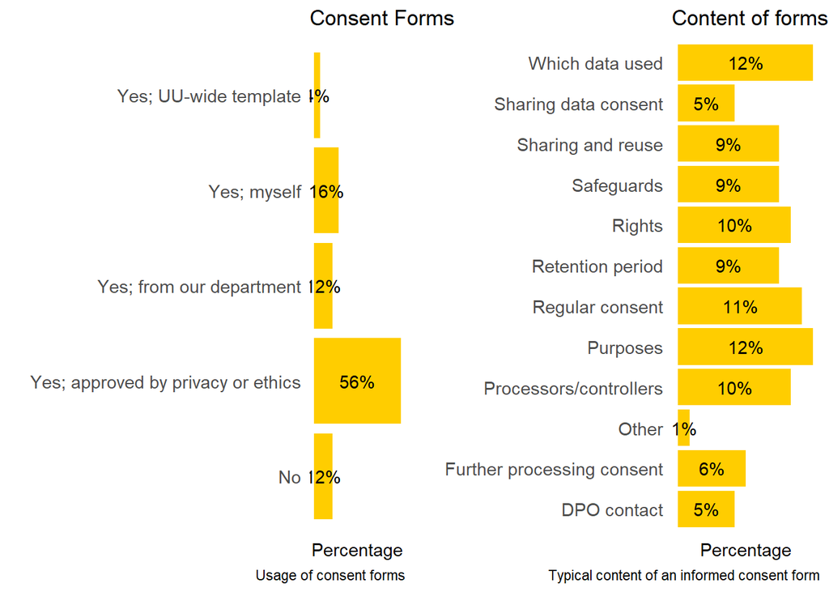

#### LEG

Below the usage and content of informed consent forms at the Faculty of Law, Economics and Governance is displayed.

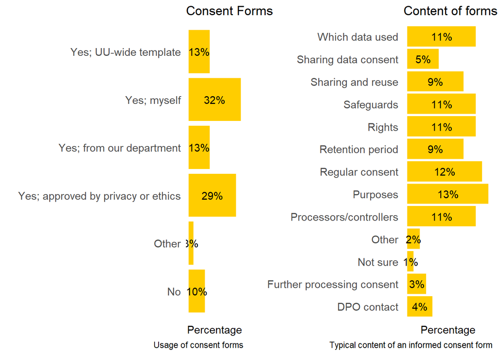

#### Geo

Below the usage and content of informed consent forms at the Faculty of Geosciences is displayed.

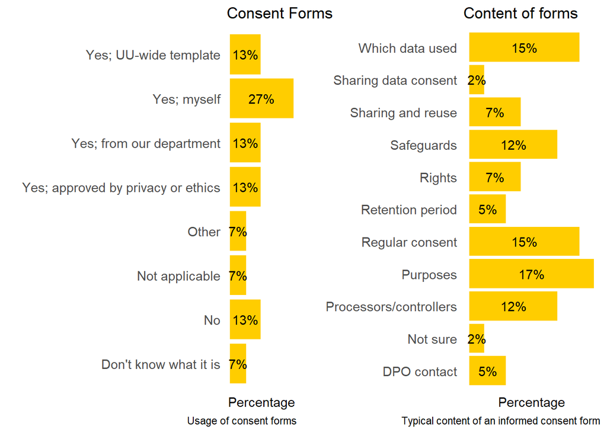

### Data Protection Impact Assessment (DPIA)

#### UU-wide

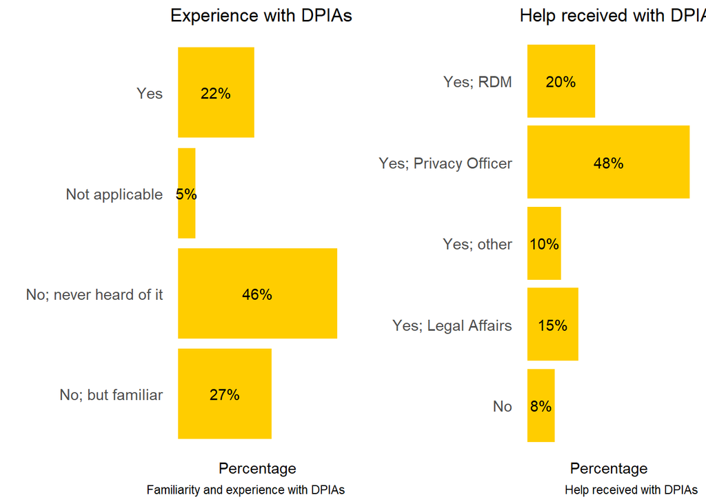

#### Science

Below the experience and help received with DPIAs is displayed for the Faculty of Science.

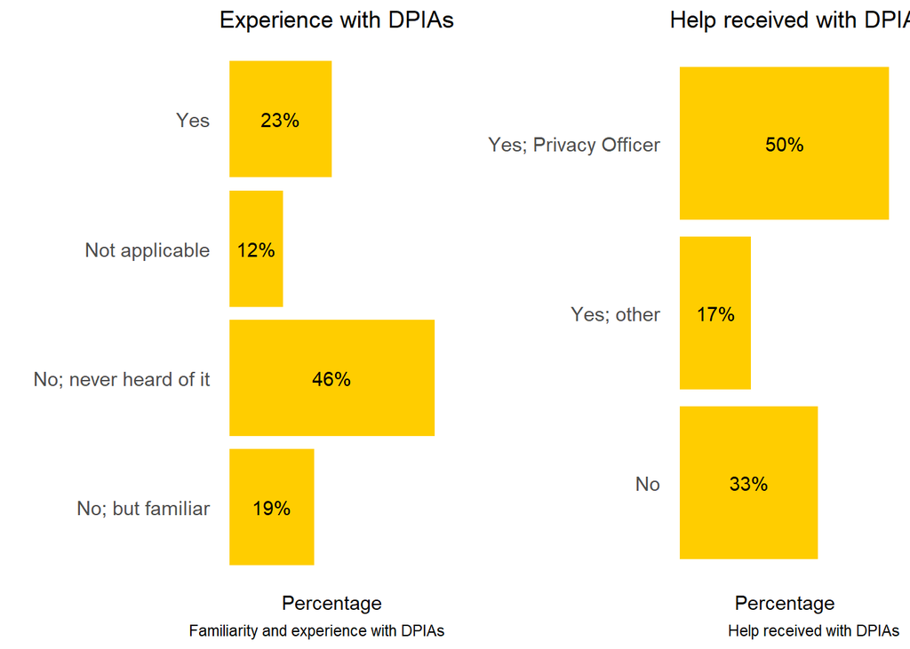

#### FBSB

Below the experience and help received with DPIAs is displayed for the Faculty of Social and Behavioural Sciences (FSBS).

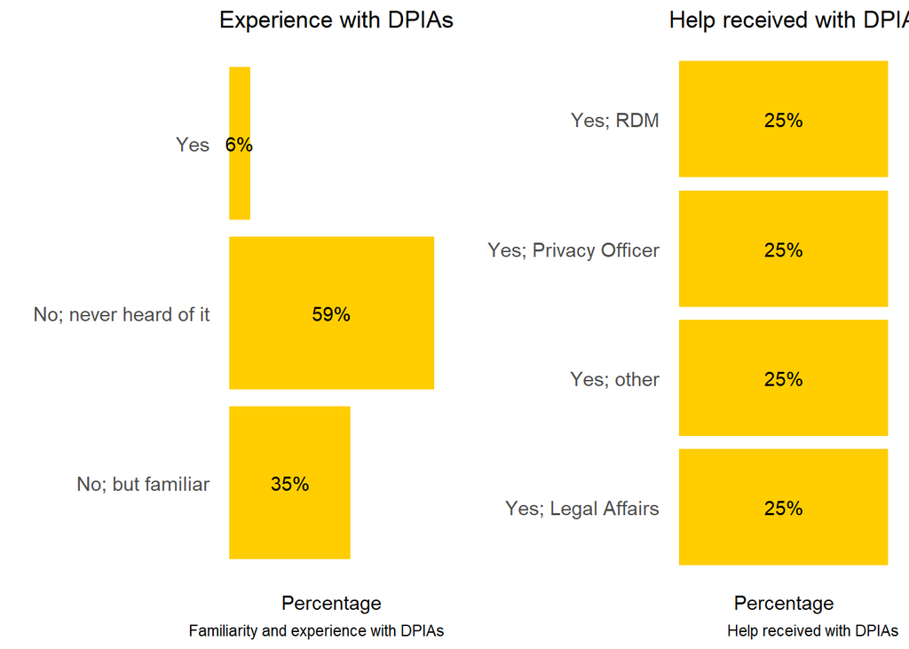

#### Humanities

Below the experience and help received with DPIAs is displayed for the Faculty of Humanities.

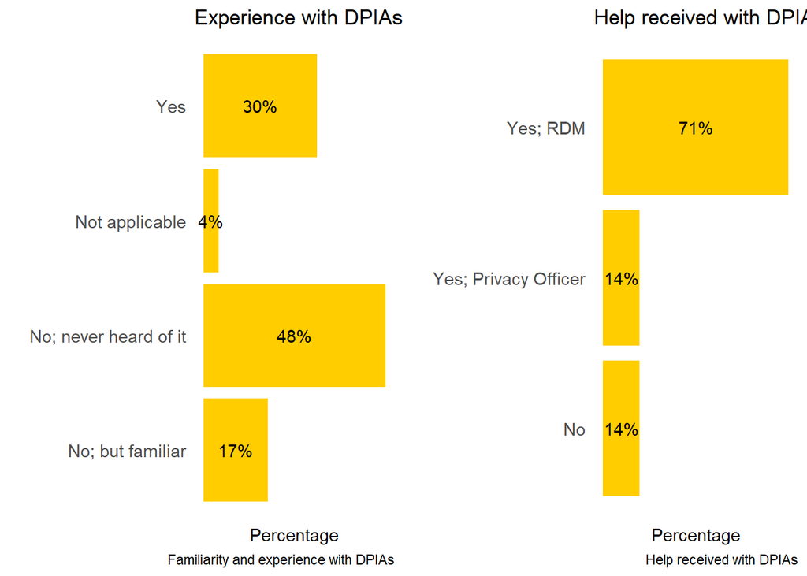

#### Veterinary Medicine

Below the experience and help received with DPIAs is displayed for the Faculty of Veterinary Medicine.

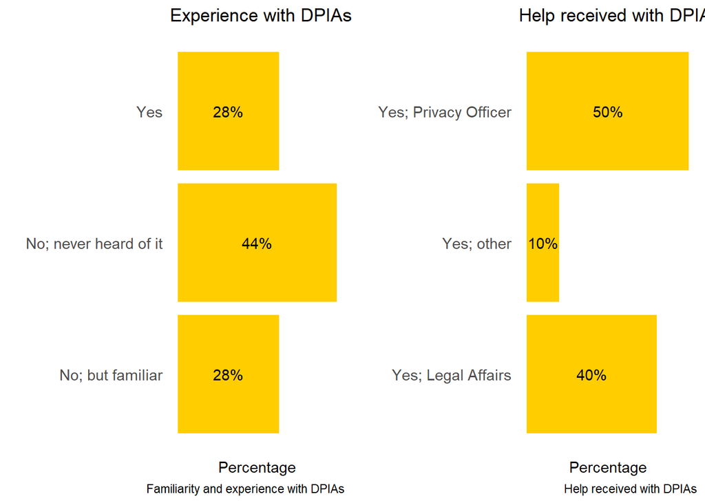

#### LEG

Below the experience and help received with DPIAs is displayed for the Faculty of Law, Economics and Governance.

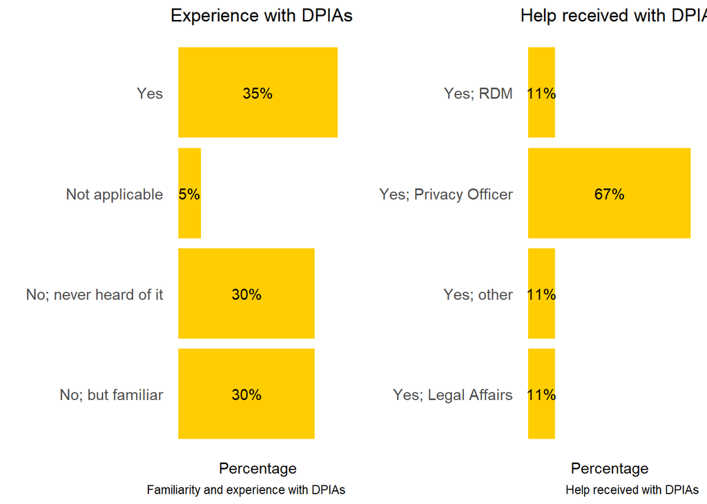

#### Geo

Below the experience and help received with DPIAs is displayed for the Faculty of Geosciences.

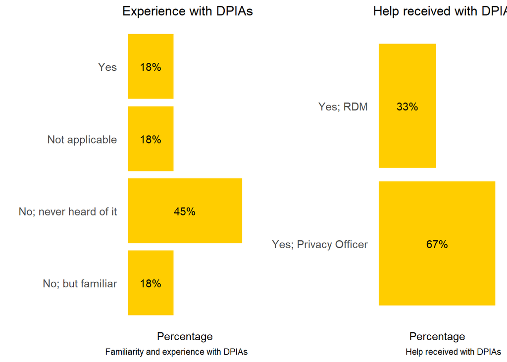

### Data sharing practices

#### UU-wide

To investigate how often data are being shared and under which circumstances, we asked respondents if and with which parties they typically share their research data, and which measures they usually take to do so securely. While there were some respondents who indicated not to share their data at all, most respondents seem to only share research data within the organisation, and otherwise within the European Economic Area (EEA). This is relatively good news, as such transfers usually require little, if any, additional safeguards. Responses in the “Other” category, however, suggest that a lot of data actually are shared, for example with co-authors at another institution, students, or in “pseudonymised form”.

Concerning the measures used before sharing data, most repondents indicated to pseudonymise their data, though we cannot assess the quality of such pseudonymisation. Researchers also seemed to use approved tools, agreements, and providing access without data transfer. Only a few respondents indicated that they involved a data expert while transferring data, and the use of Standard Contractual Clauses appears limited.

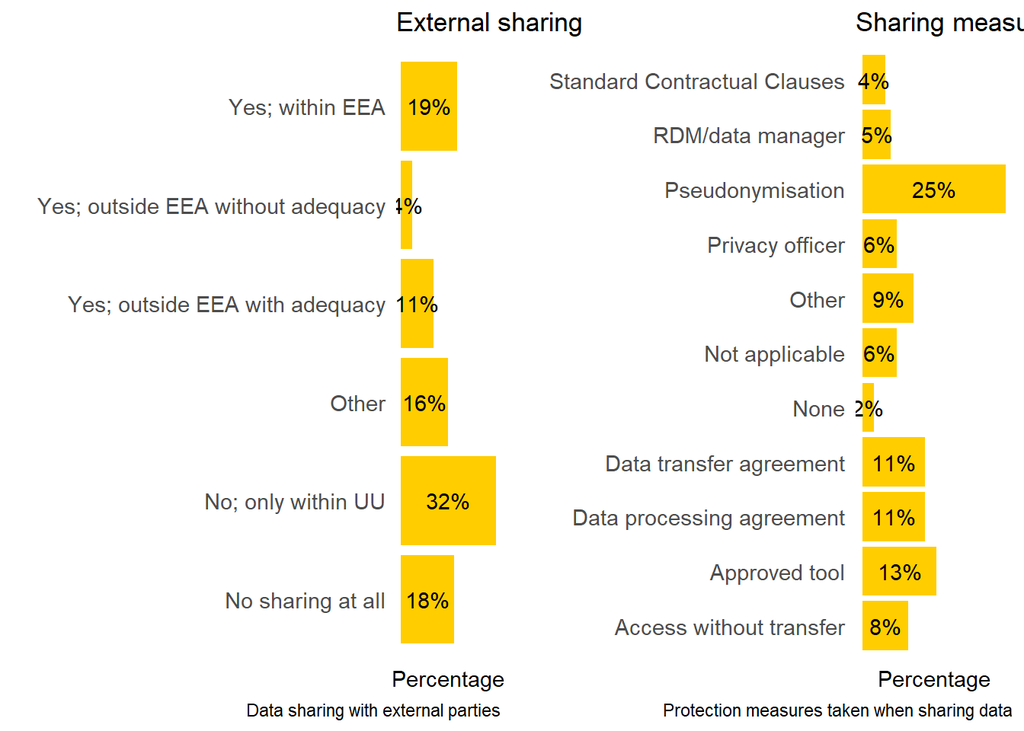

#### Science

Below the data sharing practices across the Faculty of Science are visualised.

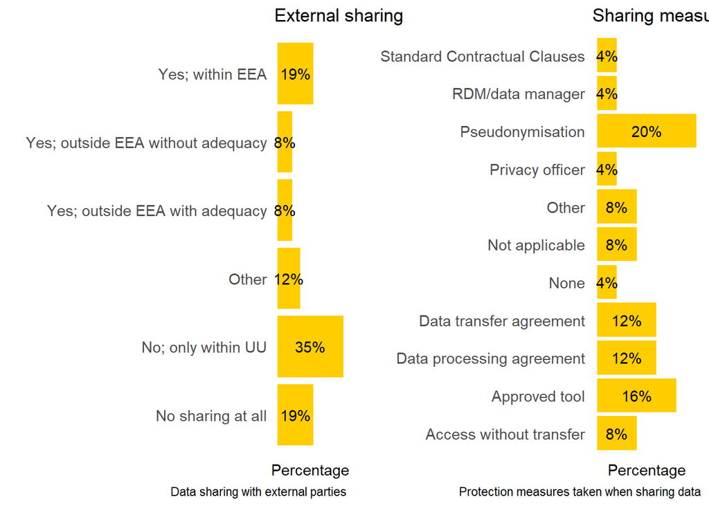

#### FBSB

Below the data sharing practices across the Faculty of Social and Behavioural Sciences (FSBS) are visualised.

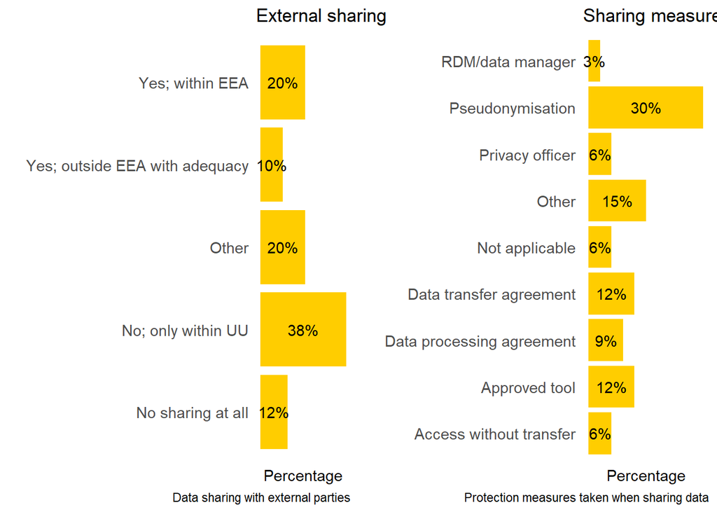

#### Humanities

Below the data sharing practices across the Faculty of Humanities are visualised.

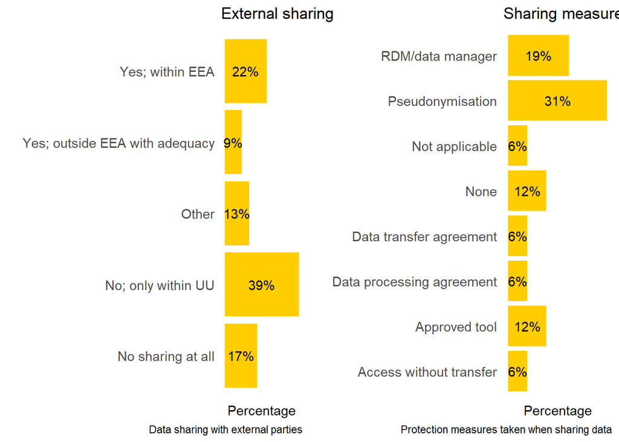

#### Veterinary Medicine

Below the data sharing practices across the Faculty of Veterinary Sciences are visualised.

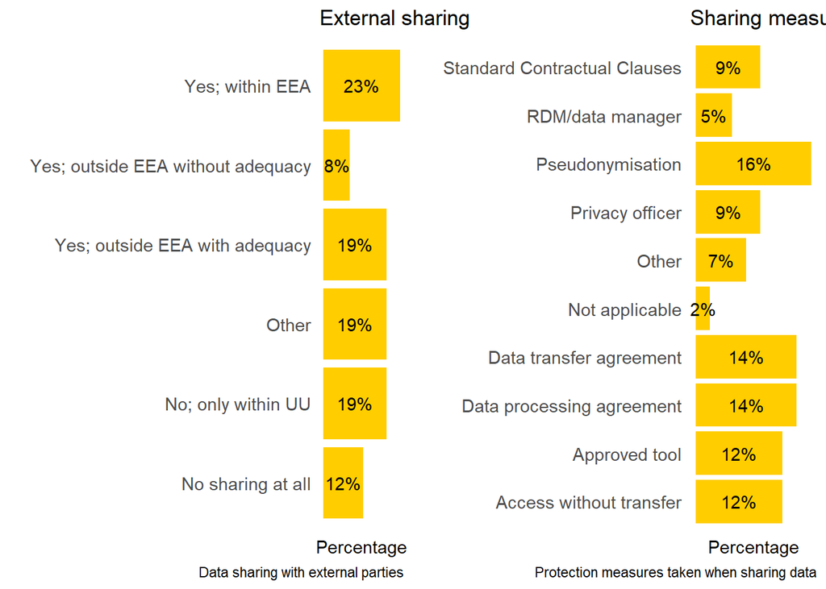

#### LEG

Below the data sharing practices across the Faculty of Law, Economics and Governance are visualised.

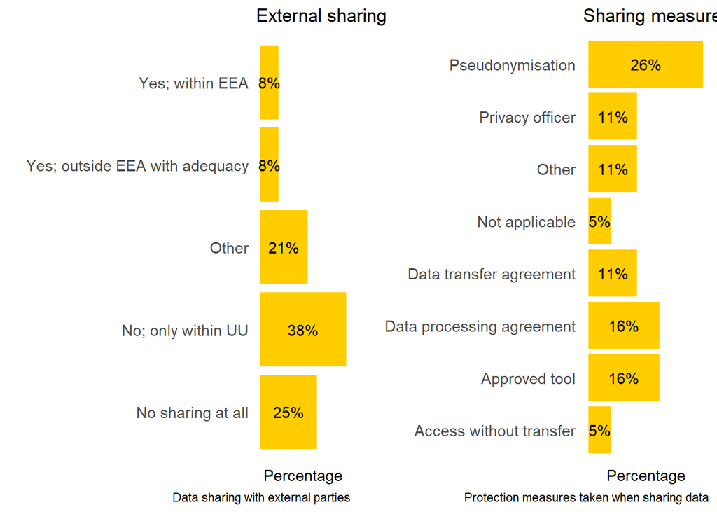

#### Geo

Below the data sharing practices across the Faculty of Geosciences are visualised.

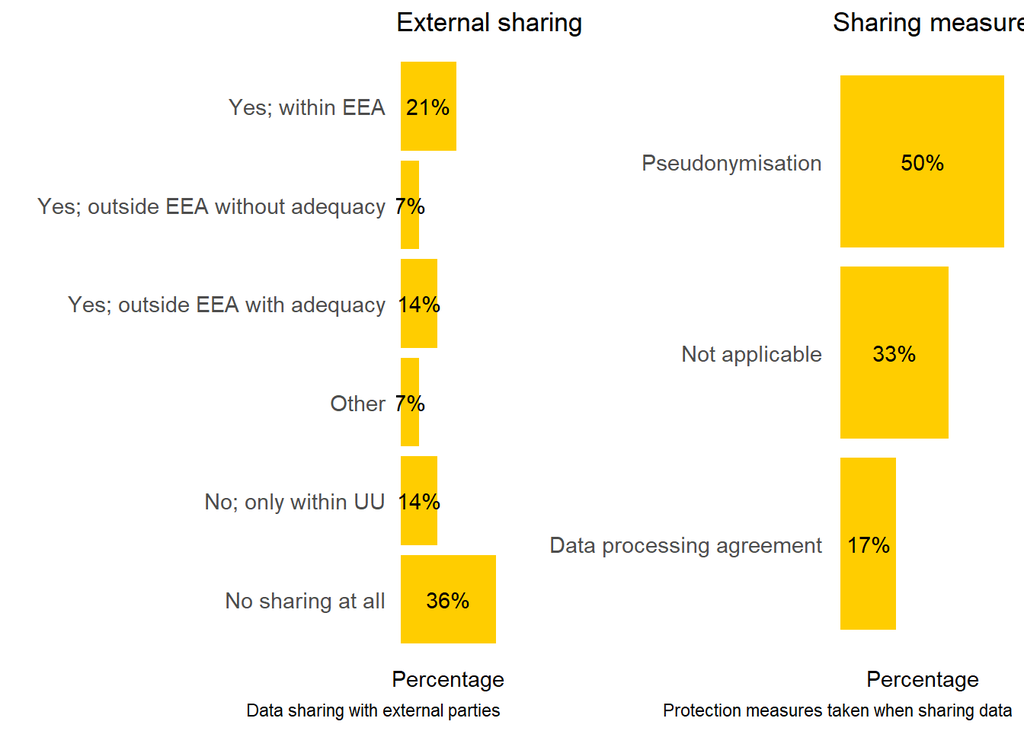

### Data publishing

#### UU-wide

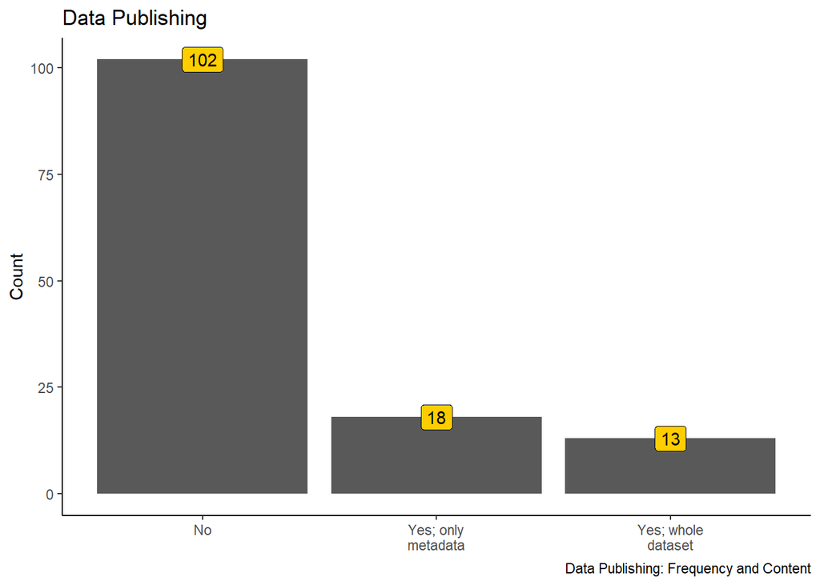

Open science and privacy are often seen as conflicting, as sharing personal data cannot be done just like that, but requires at the very least a valid legal basis and additional safeguards. Therefore, in our experience, to date not many datasets that contain personal data are shared for reuse purposes, and the survey respondents seemed to confirm this experience, as the majority of the respondents indicated not to publish their data, or only in anonymised form (again, we cannot be certain whether the data were indeed entirely anonymised).

The primary reason for not publishing data appears to be that researchers were still working on the data, they don’t want to/need to publish their data, or they cannot anonymise the data. Other reasons given by the respondents included that publishing data is too much effort, publication is undesirable, or just not considered.

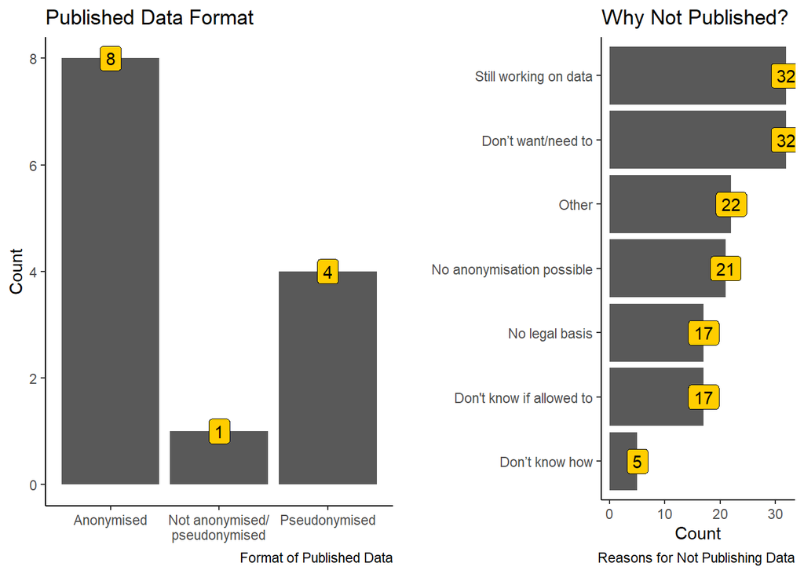

## Existing support channels

The second part of the survey concerned the visibility and use of existing support channels.

### Faculty privacy officer

When comparing faculties (see below), it is striking that the faculties where the most personal data seems to be processed, the majority of respondents is not aware of their faculty privacy officer. This suggests either that researchers have simply never required help from their privacy officer, or that the faculty privacy officers could increase their visibility within their faculties.

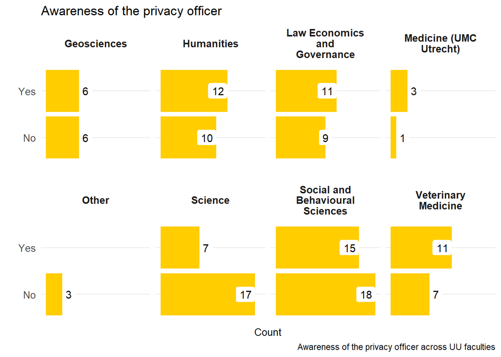

### Looking for help

#### UU-wide

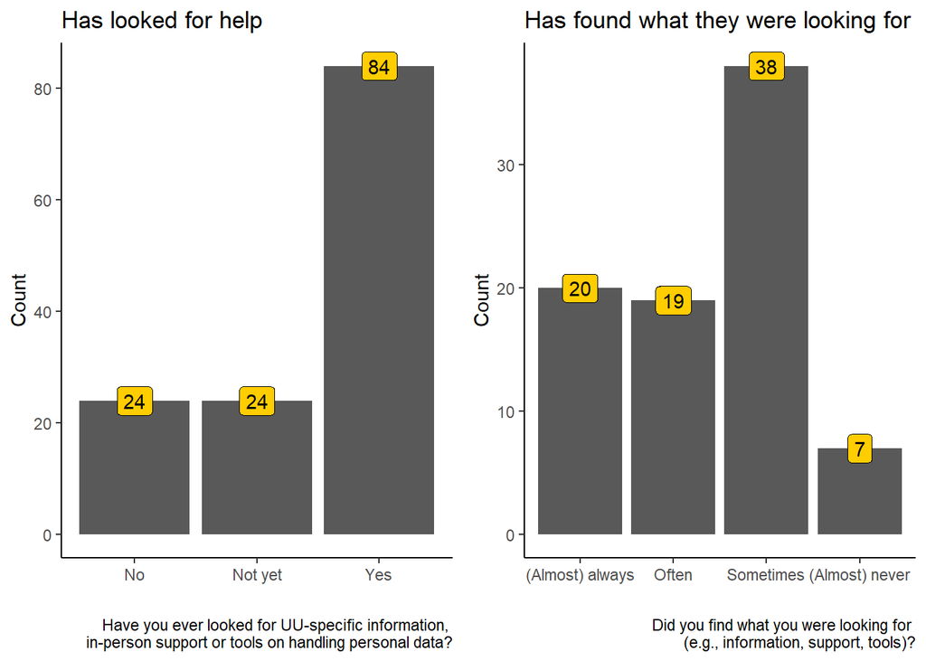

### Channels used to find support

#### UU-wide

The graph below indicates which channels respondents used most when looking for information about handling personal data. Note that this was a multiple choice question, and so the numbers do no add up to the total number of survey respondents. As shown below, all sources mentioned were to some extent consulted by the respondents. However, there is large differentiation between these sources. The university website and intranet are the most visited online resources for information about handling personal data. Notably, colleagues appear to play an important role as well in informing researchers about how to handle personal data. This suggests that the better informed researchers are, the more positive the effect is on their colleagues as well. Moreover, this also suggests that in-person support may be a more effective way of increasing awareness of privacy-related practices than more “distant” information sources.

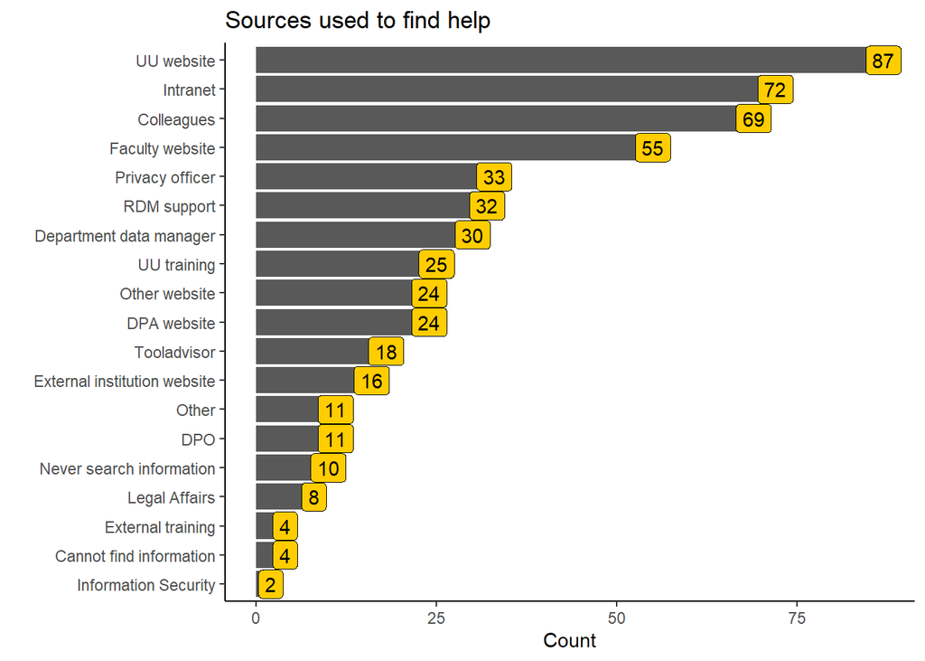

## Challenges and needs (survey)

### UU-wide

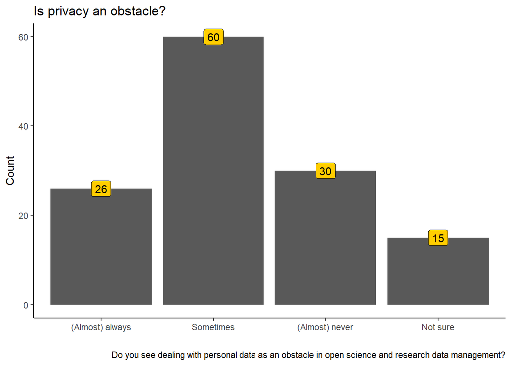

As can be seen above, most researchers experience privacy to be an obstacle for open science and research data management in some way. It is therefore important to aim for support in this area. What this support should look like, however, differs a bit. As can be seen below, accessible information and visible support channels seem to be the most wanted improvements in the current support, closely followed by UU-wide policy on the topic, and privacy-related walk-in hours.

How can we improve personal data-related services?

| bettersupport | Count | Percentage |
| --- | --- | --- |
| Information | 76 | 43.4 |
| Support visibility | 66 | 37.7 |
| UU-wide policy | 46 | 26.3 |
| Walk-ins | 34 | 19.4 |
| Workshops | 29 | 16.6 |
| Other | 27 | 15.4 |
| Support availability | 25 | 14.3 |
| Trainings | 24 | 13.7 |
| Tooling | 24 | 13.7 |

## Challenges and needs (open questions, meetings)

As mentioned in the Methods section, the responses on the following open questions, and the notes taken during the one-on-one meetings with researchers were coded to allow for easier analysis. From the survey, the following questions were coded:

- “Which challenges concerning the handling of personal data do you run into most often?”
- “What specific **information** or **tools** about handling personal data are you missing from existing sources?”
- “What can we do better to support you in handling personal data in research?” (responses to the “Other” option)

The codes that were assigned in both the survey and the meeting notes can be seen in the word cloud below: the larger the font, the more often the code was assigned. The meaning of each code is explained in the file “codes-freq_survey_meetings.csv” and below. Please note that there is overlap in respondents between the open questions in the survey and the meeting notes, and therefore some codes may have been applied twice for the same researcher.

### UU-wide

[interactive chart not shown]

**Below we go into the most frequently mentioned challenges/needs expressed by researchers in the survey (open questions) and one-one-one meetings:**

### Visibility and findability

It should be clear where to go for help (to whom or which webpage, etc.) (mentioned 27 times). Some respondents indicated not to know where to go for help with privacy-related matters, others mentioned that there should be *more* support personnel available (8). One researcher said to prefer having one place to go to for all data-related questions. As a matter of fact, many faculties have such a “one-stop-shop” in place, but responses such as these indicate that their visibility may be improved.

Closely related to visibility is findability. Many researchers point out that available information is difficult to find, or it is confusing which source should be followed. As an example, one researcher from the faculty of Humanities was determined that they found some useful information at the RDM Support website. However, upon closer inspection, it appeared that this information arose from another data management-related website with the UU logo on it.

> “UU biedt ontzettend veel aan, maar je moet veel websites bezoeken om alles te vinden […] Een duidelijk overzicht voor welke informatie je waar moet zijn zou fijn zijn.”

### Hands-on support

Many (24) researchers indicated that support staff could sometimes provide support in a more hands-on fashion, rather than abstract advice and telling researchers how *not* to do things. Some researchers added that privacy professionals sometimes have a tendency to cling to the letter of the law, leading to significant delays in their project, instead of looking at how to concretely solve existing issues in practice (mentioned 11 times):

> “Soms zijn we door deze regels heiliger dan de paus.”

> “Actual getting-your-hands-dirty support: not the kind that tells you what to do, but also the kind that helps you by doing.”

### Less bureaucracy

Processes were often experienced as time-inefficient, and sometimes longer and more bureaucratic than necessary (mentioned by 22 researchers). For example, the DPIA process was mentioned explicitly (10 times), as well as having to fill out too many forms with overlapping content (e.g., Privacy Scan, Data Management Plan, DPIA). Some (9) researchers argued that (part of) this burden should be relieved or carried by support staff:

> “Minder acties die gericht zijn op inhoudelijk trainen van WP en meer uit handen nemen van deze groep.”

> “Sharing data costs a lot of time and is inefficient when you do not do it often”

### Unclear processes and guidelines

Many (18) researchers complained that it was unclear what was expected of them when they processed personal data in their research, or that they would like to have more, or more practical guidelines (14) on this topic, for example on:

- What steps do researchers need to take? (3)
- Who should researcher ask for help in which situation?
- Who is responsible or has the authority to make the right decisions when handling personal data? Do privacy officers/DPO have to be seen as gatekeepers (similar to an ethical committee) or as advisers? Do researchers have to listen to the advise, or is that their own responsibility? (4)
- When rules change, how does that affect what researchers need to do? (1)
- Different processes for different types of research (e.g., student projects vs. large longitudinal projects, 3)

### Information and education

A large part of the respondents expressed a need for more (clear) information and education with respect to handling personal data in research. In general, researchers indicated that the information offered to them should be more clear (3), simpler 9, consistent across resources (8), possibly in the form of templates (14). Luckily, some researchers indicated to already be happy with existing materials (4).

#### Information for specific research or data types

Many researchers indicated to have a need for more tailored information for specific types of data or research (9), for example for etnographic data (2), historical data (2), or video data (3).

> “De informatie is gewoon veel te generiek, er zouden templates moeten zijn per type onderzoek.”

> “Veel templates en uitlegmodellen spreken over data, data packages en metadata, maar die woorden zijn niet ingebed in historisch onderzoek. Er ontstaat al snel verwarring over wat historici nu precies moeten met archiefmateriaal in het licht van privacy.”

#### Frequently asked questions

A selection of researchers used the space in the open questions and/or the meetings to ask knowledge-related questions. These can be used in future support efforts, such as the [Data Privacy Handbook](https://utrechtuniversity.github.io/dataprivacyhandbook), future courses, or other future information campaigns to better address researchers’ needs. Below are examples of the most commonly asked questions:

- When are data still personal (9), how to anonymise data (3), and when are data anonymised sufficiently (5)?
- What are the privacy-related requirements for students? (7)
- How to store different types of personal data? (6)
- Data sharing: what data can be shared and with whom? (7)
- How to find a balance between informing data subjects too little vs. providing too much privacy-related information that will scare them off or hurt their trust in research? (5)
- How to balance open science and privacy? (5). Related: when is reusing data fir different purposes allowed? (e.g., education data, data collected by students, 4)
- How to collaborate with multiple institutions? (4)

#### Education and onboarding

The need for more educational resources was also recognised by a selection of the respondents. Concretely, researchers could be educated more in the following ways:

- Privacy and/or research data management as part of the master or PhD curriculum (8)
- Privacy as part of the onboarding procedure of new employees (5)
- Mandatory privacy training for supervisors, principal investigators, professors, and/or teachers (4)
- A course on how to handle personal data in research (2)

> “There is no one who tells at the start of your PhD how you should handle your data. […] I think new PhD students should get a basic course on data management and privacy.”

### … or simply no issues

Notably, there were also researchers who indicated **not** to have run into issues (yet), or to have received sufficient and useful help (9). For example:

> “The data manager and privacy officer of the faculty of humanities help a lot. This support is essential!”

> “Tot nu toe heb ik niet veel problemen gehad. De institutional review board van onze afdeling kijkt altijd kritisch naar de onderzoeksvoorstellen, ook met name op omgaan met persoonsgegevens.”

# Technical information

[^1]: The Data Privacy Project is funded by Utrecht University’s Research IT program and a Digital Competence Center grant from the Dutch Organization for Scientific Research (NWO). It is led by Utrecht University’s [Research Data Management Support](https://uu.nl/rdm/), in collaboration with the University Library, Information Technology Services, first- and second-line privacy officers, information security, and others.